```python
import pylab
import pandas as pd
import statsmodels.api as sm
from scipy import stats
import matplotlib.pyplot as plt
import warnings
import itertools
warnings.filterwarnings('ignore')
%pylab inline
```

# Проведем построение прогноза по заданному алгоритму

1. Визуальный анализ ряда
2. Стабилизация дисперсии (при необходимости)
3. Выбор порядка дифференцирования
4. Выбор начальных приближений для p,q,P,Q
5. Обучение и сравнение моделей-кандидатов, выбор победителя
6. Анализ остатков построенной модели, при необходимости — её модификация: если остатки получаются смещёнными, прогноз нужно скорректировать на константу; если остатки нестационарны или автокоррелированы, можно попробовать расширить область, в которой подбираются значения p,q,P,Q.
7. Прогнозирование с помощью финальной модели.

## 1. Визуальный анализ ряда

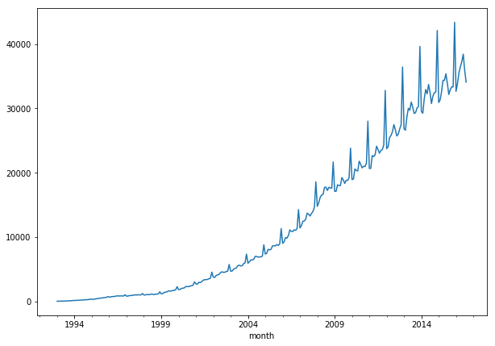

```python
WAG = pd.read_csv('WAG_C_M.csv',';', index_col=['month'], parse_dates=['month'], dayfirst=True)
plt.figure(figsize(10,7))
WAG['WAG_C_M'].plot()
```

### Рассматриваемый ряд имеет следующие характеристики:

1. Имеется хорошо выраженный повышающий тренд
2. Дисперсия ряда зависит от времени - ряд нестационарен
3. Также наблюдается годовая сезонность

## 2. Начнём со стабилизации дисперсии

```
Оптимальный параметр преобразования Бокса-Кокса: 0.263202
Критерий Дики-Фуллера: p=0.696899
```

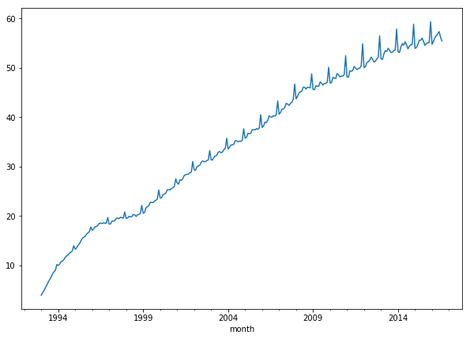

```python
def invboxcox(y,lmbda):
    if lmbda == 0:
        return(np.exp(y))
    else:
        return(np.exp(np.log(lmbda*y+1)/lmbda))

WAG['WAG_box'], lmbda = stats.boxcox(WAG.WAG_C_M)
plt.figure(figsize(10,7))
WAG.WAG_box.plot()
print("Оптимальный параметр преобразования Бокса-Кокса: %f" % lmbda)
print("Критерий Дики-Фуллера: p=%f" % sm.tsa.stattools.adfuller(WAG.WAG_box)[1])
```

В данном ряде всё еще остались тренд и сезонность. Критерий Дики-Фуллера не отвергает гипотезу о нестационарности ряда, так что придётся прибегнуть к дифференцированию.

## 3. Посмотрим как повлияет дифференцирование с различными порядками на стационарность ряда.

Начнём с сезонного дифференцирования.

```
Критерий Дики-Фуллера: p=0.014697
```

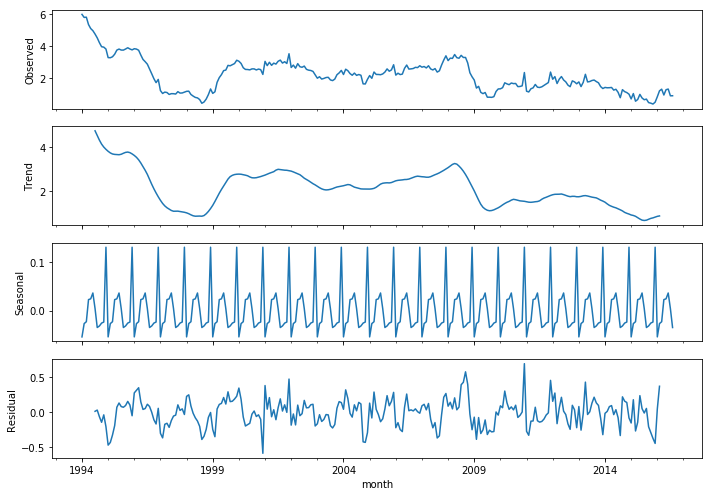

```python
WAG['WAG_box_season_diff'] = WAG.WAG_box - WAG.WAG_box.shift(12)
plt.figure(figsize(10,7))
sm.tsa.seasonal_decompose(WAG.WAG_box_season_diff[12:]).plot()
print("Критерий Дики-Фуллера: p=%f" % sm.tsa.stattools.adfuller(WAG.WAG_box_season_diff[12:])[1])
```

Тренд имеет сложную форму, а сезонность в данных сохранилась. Критерий Дики-Фуллера отвергает гипотезу о нестационарости на уровне 0.05, однако визуально ряд всё еще не выглядит достаточно хорошо. Проведем второе дифференцирование, на этот раз обычное.

```
Критерий Дики-Фуллера: p=0.000000
```

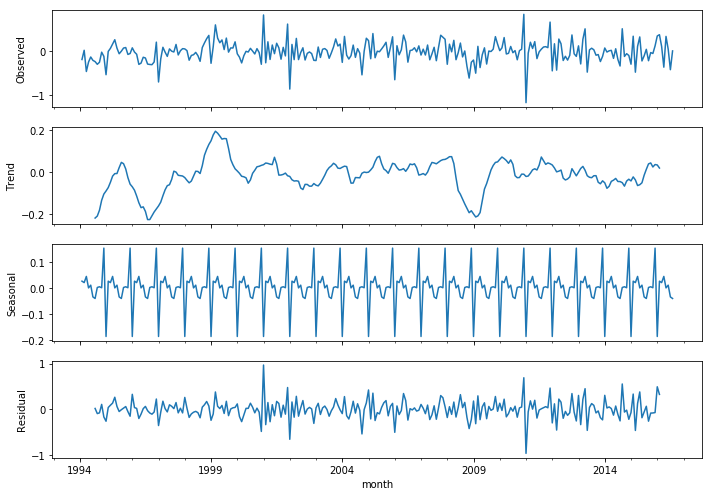

```python
WAG['WAG_box_diff'] = WAG.WAG_box_season_diff - WAG.WAG_box_season_diff.shift(1)
plt.figure(figsize(10,7))
sm.tsa.seasonal_decompose(WAG.WAG_box_diff[13:]).plot()
print("Критерий Дики-Фуллера: p=%f" % sm.tsa.stattools.adfuller(WAG.WAG_box_diff[13:])[1])
```

На этот раз тренд колеблется вокруг 0, что визуально выглядит лучше. Критерий Дики-Фуллера увереннее отвергает гипотезу о нестационарности. Остановимся в дифференцировании на данном шаге.

## 4. Подбор начальных приближений для параметров модели.

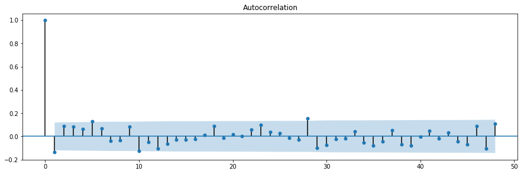

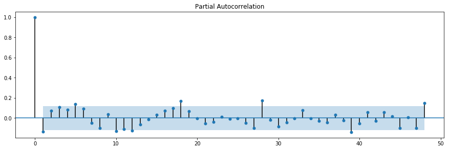

```python
plt.figure(figsize(15,10))
ax = plt.subplot(211)
sm.graphics.tsa.plot_acf(WAG.WAG_box_diff[13:].values.squeeze(), lags=48, ax=ax)
pylab.show()
ax = plt.subplot(212)
sm.graphics.tsa.plot_pacf(WAG.WAG_box_diff[13:].values.squeeze(), lags=48, ax=ax)
pylab.show()
```

В качестве начальных приближений для модели можно взять следующие:

- Q = 0
- q = 1
- P = 4
- p = 10

```python
ps = range(0, 11)
d=1
qs = range(0, 2)
Ps = range(0, 5)
D=1
Qs = range(0, 1)
```

```python
parameters = itertools.product(ps, qs, Ps, Qs)
parameters_list = list(parameters)
len(parameters_list)
```

```
110
```

## 5. Обучение и сравнение моделей-кандидатов.

```python
%%time
results = []
best_aic = float("inf")
warnings.filterwarnings('ignore')

for param in parameters_list:
    #try except нужен, потому что на некоторых наборах параметров модель не обучается
    try:
        model=sm.tsa.statespace.SARIMAX(WAG.WAG_box, order=(param[0], d, param[1]),
                                        seasonal_order=(param[2], D, param[3], 12)).fit(disp=-1)
    #выводим параметры, на которых модель не обучается и переходим к следующему набору
    except ValueError:
        print('wrong parameters:', param)
        continue
    aic = model.aic
    #сохраняем лучшую модель, aic, параметры
    if aic < best_aic:
        best_model = model
        best_aic = aic
        best_param = param
    results.append([param, model.aic])
```

```
wrong parameters: (2, 1, 0, 0)
wrong parameters: (2, 1, 1, 0)
wrong parameters: (2, 1, 2, 0)
wrong parameters: (2, 1, 3, 0)
wrong parameters: (2, 1, 4, 0)
Wall time: 4min 1s
```

```python
result_table = pd.DataFrame(results)
result_table.columns = ['parameters', 'aic']
print(result_table.sort_values(by = 'aic', ascending=True).head())
```

```
        parameters       aic
56    (6, 0, 1, 0) -7.552970
101  (10, 1, 1, 0) -7.168053
57    (6, 0, 2, 0) -6.480323
59    (6, 0, 4, 0) -6.327815
100  (10, 1, 0, 0) -5.958380
```

Как видно, лучшая модель имеет 7 параметров.

## 6. Анализ остатков с помощью критериев и визуального осмотра графиков.

```python
print(best_model.summary())
```

```
                                 Statespace Model Results
==========================================================================================
Dep. Variable:                            WAG_box   No. Observations:                  284
Model:             SARIMAX(6, 1, 0)x(1, 1, 0, 12)   Log Likelihood                  11.776
Date:                            Sun, 17 Mar 2019   AIC                             -7.553
Time:                                    01:36:23   BIC                             21.264
Sample:                                01-01-1993   HQIC                             4.017
                                     - 08-01-2016
Covariance Type:                              opg
==============================================================================
                 coef    std err          z      P>|z|      [0.025      0.975]
------------------------------------------------------------------------------
ar.L1         -0.1991      0.045     -4.401      0.000      -0.288      -0.110
ar.L2          0.0224      0.066      0.338      0.735      -0.107       0.152
ar.L3          0.1121      0.062      1.817      0.069      -0.009       0.233
ar.L4          0.1139      0.072      1.592      0.111      -0.026       0.254
ar.L5          0.1777      0.075      2.374      0.018       0.031       0.324
ar.L6          0.1429      0.078      1.827      0.068      -0.010       0.296
ar.S.L12      -0.1769      0.043     -4.119      0.000      -0.261      -0.093
sigma2         0.0535      0.004     15.210      0.000       0.047       0.060
===================================================================================
Ljung-Box (Q):                       42.25   Jarque-Bera (JB):                60.03
Prob(Q):                              0.37   Prob(JB):                         0.00
Heteroskedasticity (H):               1.72   Skew:                             0.25
Prob(H) (two-sided):                  0.01   Kurtosis:                         5.25
===================================================================================

Warnings:
[1] Covariance matrix calculated using the outer product of gradients (complex-step).
```

```
Критерий Стьюдента: p=0.293151
Критерий Дики-Фуллера: p=0.000000
```

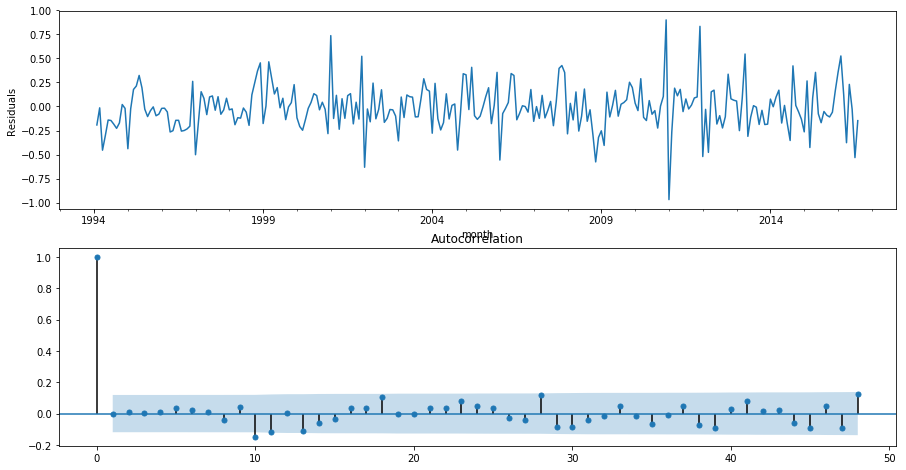

```python
plt.figure(figsize(15,8))
plt.subplot(211)
best_model.resid[13:].plot()
plt.ylabel(u'Residuals')

ax = plt.subplot(212)
sm.graphics.tsa.plot_acf(best_model.resid[13:].values.squeeze(), lags=48, ax=ax)

print("Критерий Стьюдента: p=%f" % stats.ttest_1samp(best_model.resid[13:], 0)[1])
print("Критерий Дики-Фуллера: p=%f" % sm.tsa.stattools.adfuller(best_model.resid[13:])[1])
```

Значения критериев показывают следующее - остатки несмещены(критерий Стьюдента), стационарны(критерий Дики-Фуллера) и неавтокоррелированы(критерий Льюнга-Бокса+коррелограмма). Имеющиеся значимые несезонные значения автокорреляции объясняются множественной проверкой гипотез.

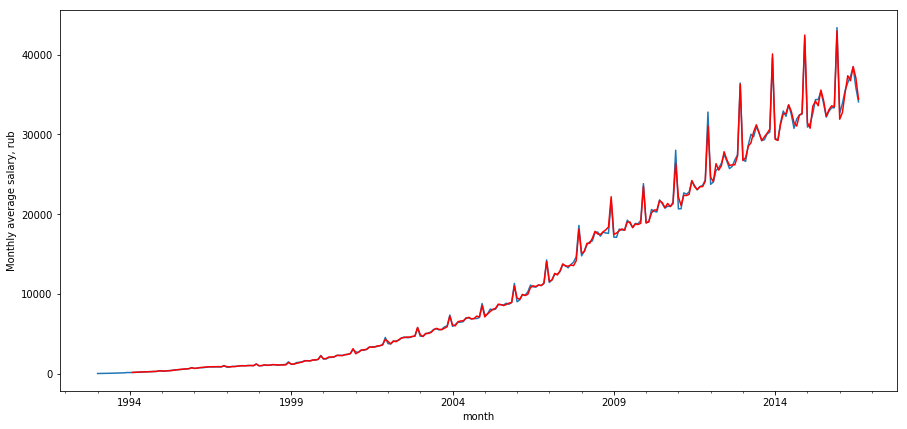

```python
WAG['model'] = invboxcox(best_model.fittedvalues, lmbda)
plt.figure(figsize(15,7))
WAG.WAG_C_M.plot()
WAG.model[13:].plot(color='r')
plt.ylabel('Monthly average salary, rub')
pylab.show()
```

Как видно, модель отлично описывает имеющиеся данные. Приступим к последнему шагу.

## 7. Построение прогноза на каждый месяц вперёд на 2 года с конца данных.

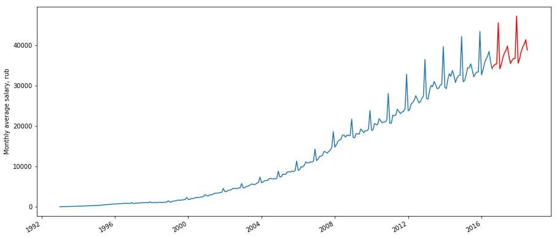

```python
WAG2 = WAG[['WAG_C_M']]
date_list = [datetime.datetime.strptime("2016-08-01", "%Y-%m-%d") + relativedelta(months=x) for x in range(0,24)]
future = pd.DataFrame(index=date_list, columns= WAG2.columns)
WAG2 = pd.concat([WAG2, future])
WAG2['forecast'] = invboxcox(best_model.predict(start=283, end=306), lmbda)

plt.figure(figsize(15,7))
WAG2.WAG_C_M.plot()
WAG2.forecast.plot(color='r')
plt.ylabel('Monthly average salary, rub')
pylab.show()
```

## Вывод.

Как видно из данных, модель хорошо учитывает 2 фактора - сезонность и восходящий тренд. Однако, плохо учитывает нашу экономику(